# User Study

```python
import random
import numpy as np
import matplotlib.pyplot as plt
import seaborn as sns
import pandas as pd
import harmonicsonification as hs
hs.seed_everything(42)
```

## Data Set Creation

We want to test whether our harmonic sonification approach allows users to distinguish typical data points from outliers just based on the sound. For this, we first create an artificial data set with the characteristics typically obtained from applying PCA (i.e. dimensions with decreasing variance). We then create an *outlier* data set with uniformly distributed points (some of these points will be like typical data points, but most will fall outside the distribution).

```
16 dimensions
100 data points
std: [1.   0.77 0.59 0.45 0.34 0.26 0.2  0.15 0.12 0.09 0.07 0.05 0.04 0.03
 0.02 0.02]
outliers in [-3, 3]
```

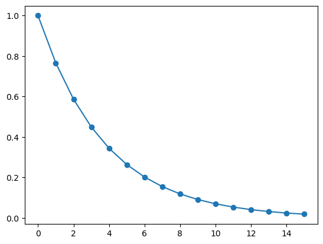

```python
dim = 16                               # dimensions
n_data = 100                           # number of data points
std = np.exp(-np.linspace(0, 4, dim))  # standard deviations
uniform = 3                            # width of the uniform outlier distribution

columns = [f"dim {i + 1}" for i in range(dim)]
data = pd.DataFrame(np.random.normal(size=(n_data, dim)) * std, columns=columns)
outlier = pd.DataFrame(np.random.uniform(-uniform, uniform, size=(n_data, dim)), columns=columns)
data['type'] = 'data'
outlier['type'] = 'outlier'
print(f"{dim} dimensions")
print(f"{n_data} data points")
print(f"std: {std.round(2)}")
print(f"outliers in [-{uniform}, {uniform}]")
plt.plot(std, '-o');
```

We can create scatter plots for all pairs of dimensions, which gives a rough idea of the two distributions.

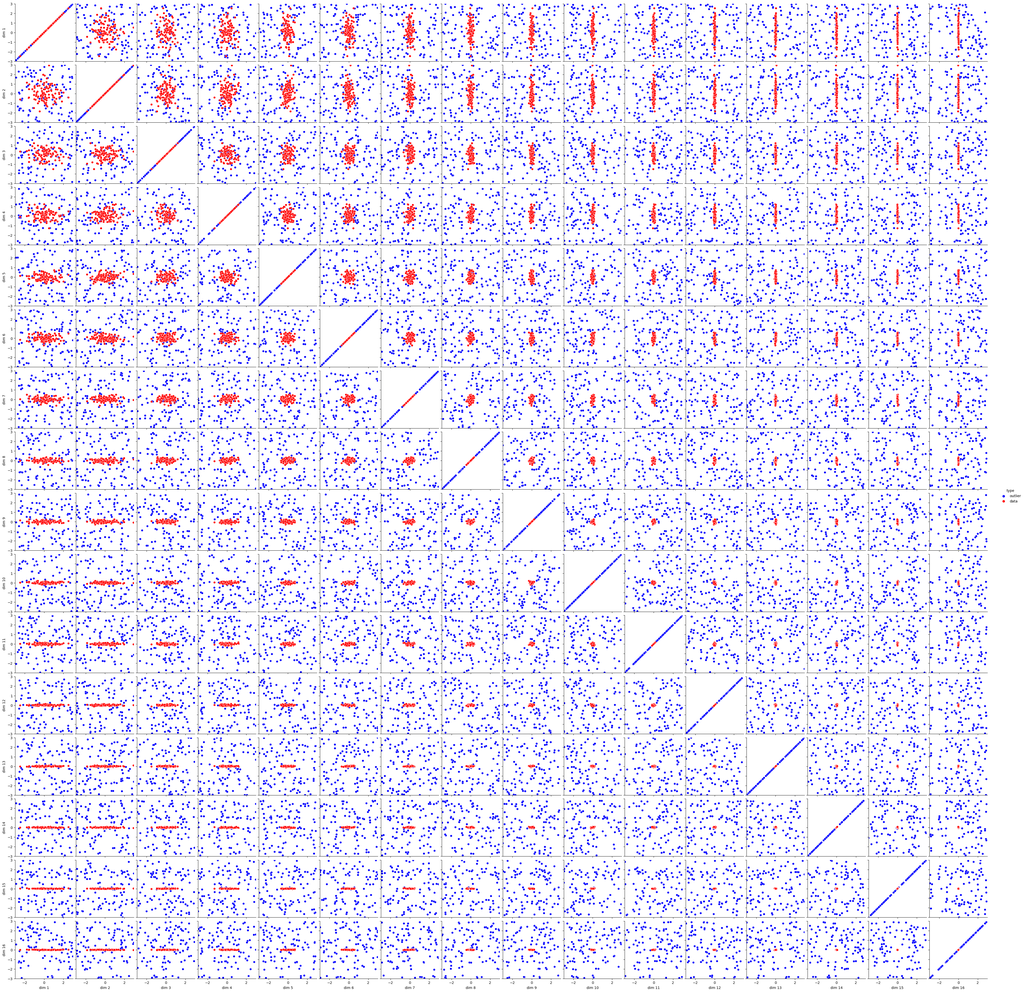

```python
combined = pd.concat([outlier, data], ignore_index=True)
p = sns.pairplot(combined, hue='type', palette=['blue', 'red'], diag_kind=None)
for ax in p.axes.flatten():
    ax.set_xlim(-uniform, uniform)
    ax.set_ylim(-uniform, uniform)
```

## Sonification

```python
base_freq = 110
amps = np.zeros(dim)
amps[-1] = 1
hs.sonify_am(x=amps, f0=base_freq).display()
```

[interactive chart not shown]

Helper functions to extract data points, randomise their order (for the experiment), and sonify them

```python
def get_points(data, outlier, shuffle):
    points = []
    for d, l in [(data, 'data'), (outlier, 'outlier')]:
        if d is not None:
            d = d[:,:-1]
            points += [(d, f'{l} {i + 1}') for i, d in enumerate(d)]
    if shuffle:
        random.shuffle(points)
    points, labels = list(zip(*points))
    return np.array(points), labels
```

```python
def sonify(points, labels, std, base_freq, add_fundamental=True, label=False, print_amps=False):
    points = np.abs(points)
    points /= std[None, :]
    points /= points.max()
    for i, (p, l) in enumerate(zip(points, labels)):
        if add_fundamental:
            amps = [1] + list(p)
        else:
            amps = p
        amps = np.array(amps, dtype=float)
        if label:
            print(l)
        else:
            print(f"point {i + 1}")
        if print_amps:
            print(amps.round(2))
        hs.sonify_am(x=amps, f0=base_freq).display()
```

### Example Data

Here are some typical data points as well as some outliers.

```python
n_examples = 5
points, labels = get_points(data.values[:n_examples], outlier.values[:n_examples], False)
```

```python
sonify(points, labels, std, base_freq, label=True)
```

```
data 1
```

[interactive chart not shown]

```
data 2
```

[interactive chart not shown]

```
data 3
```

[interactive chart not shown]

```
data 4
```

[interactive chart not shown]

```
data 5
```

[interactive chart not shown]

```
outlier 1
```

[interactive chart not shown]

```
outlier 2
```

[interactive chart not shown]

```
outlier 3
```

[interactive chart not shown]

```
outlier 4
```

[interactive chart not shown]

```
outlier 5
```

[interactive chart not shown]

### Trials

Now we get some data points and outliers shuffle them randomly and let participants guess.

```python
n_test = 10
points, labels = get_points(data=data.values[n_examples:n_examples+n_test],
                            outlier=outlier.values[n_examples:n_examples+n_test],
                            shuffle=True)
```

For the evaluation, we once print their correct labels.

```python
for l in labels:
    print(l)
print("--------------------")
sonify(points, labels, std, base_freq, label=True)
```

```
outlier 10
data 6
outlier 5
data 5
data 10
outlier 4
outlier 6
outlier 9
data 7
outlier 3
outlier 8
outlier 1
data 2
outlier 2
data 3
outlier 7
data 8
data 9
data 1
data 4
--------------------
outlier 10
```

[interactive chart not shown]

```
data 6
```

[interactive chart not shown]

```
outlier 5
```

[interactive chart not shown]

```
data 5
```

[interactive chart not shown]

```
data 10
```

[interactive chart not shown]

```
outlier 4
```

[interactive chart not shown]

```
outlier 6
```

[interactive chart not shown]

```
outlier 9
```

[interactive chart not shown]

```
data 7
```

[interactive chart not shown]

```
outlier 3
```

[interactive chart not shown]

```
outlier 8
```

[interactive chart not shown]

```
outlier 1
```

[interactive chart not shown]

```
data 2
```

[interactive chart not shown]

```
outlier 2
```

[interactive chart not shown]

```
data 3
```

[interactive chart not shown]

```
outlier 7
```

[interactive chart not shown]

```
data 8
```

[interactive chart not shown]

```
data 9
```

[interactive chart not shown]

```
data 1
```

[interactive chart not shown]

```
data 4
```

[interactive chart not shown]

Now we just print a point index (this is shown to the participants)

```python
sonify(points, labels, std, base_freq)
```

```
point 1
```

[interactive chart not shown]

```
point 2
```

[interactive chart not shown]

```
point 3
```

[interactive chart not shown]

```
point 4
```

[interactive chart not shown]

```
point 5
```

[interactive chart not shown]

```
point 6
```

[interactive chart not shown]

```
point 7
```

[interactive chart not shown]

```
point 8
```

[interactive chart not shown]

```
point 9
```

[interactive chart not shown]

```
point 10
```

[interactive chart not shown]

```
point 11
```

[interactive chart not shown]

```
point 12
```

[interactive chart not shown]

```
point 13
```

[interactive chart not shown]

```
point 14
```

[interactive chart not shown]

```
point 15
```

[interactive chart not shown]

```
point 16
```

[interactive chart not shown]

```
point 17
```

[interactive chart not shown]

```
point 18
```

[interactive chart not shown]

```
point 19
```

[interactive chart not shown]

```
point 20
```

[interactive chart not shown]